# Preparation and Descriptive Analysis of Texts

Kenneth Benoit and Paul Nulty

27 October 2016

Here we will step through the basic elements of preparing a text for analysis. These are tokenization, conversion to lower case, stemming, removing or selecting features, and defining equivalency classes for features, including the use of dictionaries.

### 1. Tokenization

Tokenization in **quanteda** is very *conservative*: by default, it only removes separator characters.

```r
require(quanteda, quietly = TRUE, warn.conflicts = FALSE)
txt <- c(text1="This is $10 in 999 different ways,\n up and down; left and right!",
         text2="@kenbenoit working: on #quanteda 2day\t4ever, http://textasdata.com?page=123.")
tokenize(txt)
```

```
## tokenizedText object from 2 documents.
## text1 :
##  [1] "This"      "is"        "$"         "10"        "in"
##  [6] "999"       "different" "ways"      ","         "up"
## [11] "and"       "down"      ";"         "left"      "and"
## [16] "right"     "!"
##
## text2 :
##  [1] "@kenbenoit"     "working"        ":"              "on"
##  [5] "#quanteda"      "2day"           "4ever"          ","
##  [9] "http"           ":"              "/"              "/"
## [13] "textasdata.com" "?"              "page"           "="
## [17] "123"            "."
```

```r
tokenize(txt, verbose=TRUE)
```

```
## Starting tokenization...
```

```
## ...preserving Twitter characters (#, @)
```

```
## ...total elapsed: 0.00100000000000033 seconds.
```

```
## ...tokenizing texts
```

```
##
##   ...removing separators.
```

```
## ...total elapsed:  0.00100000000000033 seconds.
```

```
## ...replacing Twitter characters (#, @)
```

```
## ...total elapsed: 0 seconds.
```

```
## ...replacing names
```

```
## ...total elapsed:  0 seconds.
```

```
## Finished tokenizing and cleaning 2 texts.
```

```
## tokenizedText object from 2 documents.
## text1 :
##  [1] "This"      "is"        "$"         "10"        "in"
##  [6] "999"       "different" "ways"      ","         "up"
## [11] "and"       "down"      ";"         "left"      "and"
## [16] "right"     "!"
##
## text2 :
##  [1] "@kenbenoit"     "working"        ":"              "on"
##  [5] "#quanteda"      "2day"           "4ever"          ","
##  [9] "http"           ":"              "/"              "/"
## [13] "textasdata.com" "?"              "page"           "="
## [17] "123"            "."
```

```r
tokenize(txt, removeNumbers=TRUE, removePunct=TRUE)
```

```
## tokenizedText object from 2 documents.
## text1 :
##  [1] "This"      "is"        "in"        "different" "ways"
##  [6] "up"        "and"       "down"      "left"      "and"
## [11] "right"
##
## text2 :
## [1] "@kenbenoit"     "working"        "on"             "#quanteda"
## [5] "2day"           "4ever"          "http"           "textasdata.com"
## [9] "page"
```

```r
tokenize(txt, removeNumbers=FALSE, removePunct=TRUE)
```

```
## tokenizedText object from 2 documents.
## text1 :
##  [1] "This"      "is"        "10"        "in"        "999"
##  [6] "different" "ways"      "up"        "and"       "down"
## [11] "left"      "and"       "right"
##
## text2 :
##  [1] "@kenbenoit"     "working"        "on"             "#quanteda"
##  [5] "2day"           "4ever"          "http"           "textasdata.com"
##  [9] "page"           "123"
```

```r
tokenize(txt, removeNumbers=TRUE, removePunct=FALSE)
```

```
## tokenizedText object from 2 documents.
## text1 :
##  [1] "This"      "is"        "$"         "in"        "different"
##  [6] "ways"      ","         "up"        "and"       "down"
## [11] ";"         "left"      "and"       "right"     "!"
##
## text2 :
##  [1] "@kenbenoit"     "working"        ":"              "on"
##  [5] "#quanteda"      "2day"           "4ever"          ","
##  [9] "http"           ":"              "/"              "/"
## [13] "textasdata.com" "?"              "page"           "="
## [17] "."
```

```r
tokenize(txt, removeNumbers=FALSE, removePunct=FALSE)
```

```
## tokenizedText object from 2 documents.
## text1 :
##  [1] "This"      "is"        "$"         "10"        "in"
##  [6] "999"       "different" "ways"      ","         "up"
## [11] "and"       "down"      ";"         "left"      "and"
## [16] "right"     "!"
##
## text2 :
##  [1] "@kenbenoit"     "working"        ":"              "on"
##  [5] "#quanteda"      "2day"           "4ever"          ","
##  [9] "http"           ":"              "/"              "/"
## [13] "textasdata.com" "?"              "page"           "="
## [17] "123"            "."
```

```r
tokenize(txt, removeNumbers=FALSE, removePunct=FALSE, removeSeparators=FALSE)
```

```
## tokenizedText object from 2 documents.
## text1 :
##  [1] "This"      " "         "is"        " "         "$"
##  [6] "10"        " "         "in"        " "         "999"
## [11] " "         "different" " "         "ways"      ","
## [16] "\n"        " "         "up"        " "         "and"
## [21] " "         "down"      ";"         " "         "left"
## [26] " "         "and"       " "         "right"     "!"
##
## text2 :
##  [1] "@kenbenoit"     " "              "working"        ":"
##  [5] " "              "on"             " "              "#quanteda"
##  [9] " "              "2day"           "\t"             "4ever"
## [13] ","              " "              "http"           ":"
## [17] "/"              "/"              "textasdata.com" "?"
## [21] "page"           "="              "123"            "."
```

There are several options to the `what` argument:

```r
# sentence level
tokenize(c("Kurt Vongeut said; only assholes use semi-colons.",
           "Today is Thursday in Canberra:  It is yesterday in London.",
           "Today is Thursday in Canberra:  \nIt is yesterday in London.",
           "To be?  Or\not to be?"),
          what = "sentence")
```

```
## tokenizedText object from 4 documents.
## Component 1 :
## [1] "Kurt Vongeut said; only assholes use semi-colons."
##
## Component 2 :
## [1] "Today is Thursday in Canberra:  It is yesterday in London."
##
## Component 3 :
## [1] "Today is Thursday in Canberra:   It is yesterday in London."
##
## Component 4 :
## [1] "To be?"       "Or ot to be?"
```

```r
tokenize(inaugTexts[2], what = "sentence")
```

```
## tokenizedText object from 1 document.
## 1793-Washington :
## [1] "Fellow citizens, I am again called upon by the voice of my country to execute the functions of its Chief Magistrate."
## [2] "When the occasion proper for it shall arrive, I shall endeavor to express the high sense I entertain of this distinguished honor, and of the confidence which has been reposed in me by the people of united America."
## [3] "Previous to the execution of any official act of the President the Constitution requires an oath of office."
## [4] "This oath I am now about to take, and in your presence: That if it shall be found during my administration of the Government I have in any instance violated willingly or knowingly the injunctions thereof, I may (besides incurring constitutional punishment) be subject to the upbraidings of al…
```

```r
# character level
tokenize("My big fat text package.", what="character")
```

```
## tokenizedText object from 1 document.
## Component 1 :
##  [1] "M" "y" "b" "i" "g" "f" "a" "t" "t" "e" "x" "t" "p" "a" "c" "k" "a"
## [18] "g" "e" "."
```

```r
tokenize("My big fat text package.", what="character", removeSeparators=FALSE)
```

```
## tokenizedText object from 1 document.
## Component 1 :
##  [1] "M" "y" " " "b" "i" "g" " " "f" "a" "t" " " "t" "e" "x" "t" " " "p"
## [18] "a" "c" "k" "a" "g" "e" "."
```

Two other options, for really fast and simple tokenization are `"fastestword"` and `"fasterword"`, if performance is a key issue. These are less intelligent than the boundary detection used in the default `"word"` method, which is based on stringiboundary detection.

### 2. Conversion to lower case

This is a tricky one in our workflow, since it is a form of equivalency declaration, rather than a tokenization step. It turns out that it is more efficient to perform at the pre-tokenization stage.

As a result, the method `toLower()` is defined for many classes of quanteda objects.

```r
methods(toLower)
```

```
## [1] toLower.character*      toLower.corpus*         toLower.NULL*
## [4] toLower.tokenizedTexts*
## see '?methods' for accessing help and source code
```

We include options designed to preserve acronyms.

```r
test1 <- c(text1 = "England and France are members of NATO and UNESCO",
           text2 = "NASA sent a rocket into space.")
toLower(test1)
```

```
##                                               text1
## "england and france are members of nato and unesco"
##                                               text2
##                    "nasa sent a rocket into space."
```

```r
toLower(test1, keepAcronyms = TRUE)
```

```
##                                               text1
## "england and france are members of NATO and UNESCO"
##                                               text2
##                    "NASA sent a rocket into space."
```

```r
test2 <- tokenize(test1, removePunct = TRUE)
toLower(test2)
```

```
## tokenizedText object from 2 documents.
## text1 :
## [1] "england" "and"     "france"  "are"     "members" "of"      "nato"
## [8] "and"     "unesco"
##
## text2 :
## [1] "nasa"   "sent"   "a"      "rocket" "into"   "space"
```

```r
toLower(test2, keepAcronyms = TRUE)
```

```
## tokenizedText object from 2 documents.
## text1 :
## [1] "england" "and"     "france"  "are"     "members" "of"      "NATO"
## [8] "and"     "UNESCO"
##
## text2 :
## [1] "NASA"   "sent"   "a"      "rocket" "into"   "space"
```

toLower is based on stringi, and is therefore nicely Unicode compliant.

```r
# Russian
cat(iconv(encodedTexts[8], "windows-1251", "UTF-8"))
```

```
## "8-битные" oncodings являются частью прошлого. 0€. Дефис-ели. Тильда ~ тире - и ± § 50.
```

```r
cat(toLower(iconv(encodedTexts[8], "windows-1251", "UTF-8")))
```

```
## "8-битные" oncodings являются частью прошлого. 0€. дефис-ели. тильда ~ тире - и ± § 50.
```

```r
head(toLower(stopwords("russian")), 20)
```

```
##  [1] "и"   "в"   "во"  "не"  "что" "он"  "на"  "я"   "с"   "со"  "как"
## [12] "а"   "то"  "все" "она" "так" "его" "но"  "да"  "ты"
```

```r
# Arabic
cat(iconv(encodedTexts[6], "ISO-8859-6", "UTF-8"))
```

```
## ترميزات 8 بت هي موديل قديم. 0 . الواصلة أكل. تيلدا ~ م اندفاعة - و  50 .
```

```r
cat(toLower(iconv(encodedTexts[6], "ISO-8859-6", "UTF-8")))
```

```
## ترميزات 8 بت هي موديل قديم. 0 . الواصلة أكل. تيلدا ~ م اندفاعة - و  50 .
```

```r
head(toLower(stopwords("arabic")), 20)
```

```
##  [1] "فى"    "في"    "كل"    "لم"    "لن"    "له"    "من"    "هو"
##  [9] "هي"    "قوة"   "كما"   "لها"   "منذ"   "وقد"   "ولا"   "نفسه"
## [17] "لقاء"  "مقابل" "هناك"  "وقال"
```

**Note**: dfm, the Swiss army knife, converts to lower case by default, but this can be turned off using the `toLower = FALSE` argument.

### 3. Removing and selecting features

This can be done when creating a dfm:

```r
# with English stopwords and stemming
dfmsInaug2 <- dfm(subset(inaugCorpus, Year > 1980),
                  ignoredFeatures = stopwords("english"), stem = TRUE)
```

```
## Creating a dfm from a corpus ...
```

```
##
##    ... lowercasing
```

```
##
##    ... tokenizing
```

```
##
##    ... indexing documents: 9 documents
```

```
##
##    ... indexing features:
```

```
## 3,114 feature types
```

```
## ...
```

```
## removed 128 features, from 174 supplied (glob) feature types
```

```
## ... stemming features (English)
```

[output not shown]

## , trimmed 781 feature variants

## … created a 9 x 2205 sparse dfm

## Elapsed time: 0.255 seconds.

[output not shown]

[output not shown]

```
## Document-feature matrix of: 2 documents, 6 features.
## 2 x 6 sparse Matrix of class "dfmSparse"
##        features
## docs    My Christmas was by Does United_States
##   text1  1         1   1  1    0             0
##   text2  0         0   0  0    1             1
```

```r
selectFeatures(myDfm, c("s$", ".y"), "remove", valuetype = "regex")
```

```
## removed 6 features, from 2 supplied (regex) feature types
```

```
## Document-feature matrix of: 2 documents, 12 features.
## 2 x 12 sparse Matrix of class "dfmSparse"
##        features
## docs    ruined your opposition tax plan the or Sweden have more
##   text1      1    1          1   1    1   0  0      0    0    0
##   text2      0    0          0   0    0   1  1      1    1    1
##        features
## docs    progressive taxation
##   text1           0        0
##   text2           1        1
```

```r
selectFeatures(myDfm, stopwords("english"), "keep", valuetype = "fixed")
```

```
## kept 9 features, from 174 supplied (fixed) feature types
```

```
## Document-feature matrix of: 2 documents, 9 features.
## 2 x 9 sparse Matrix of class "dfmSparse"
##        features
## docs    My was by your Does the or have more
##   text1  1   1  1    1    0   0  0    0    0
##   text2  0   0  0    0    1   1  1    1    1
```

```r
selectFeatures(myDfm, stopwords("english"), "remove", valuetype = "fixed")
```

```
## removed 9 features, from 174 supplied (fixed) feature types
```

```
## Document-feature matrix of: 2 documents, 9 features.
## 2 x 9 sparse Matrix of class "dfmSparse"
##        features
## docs    Christmas ruined opposition tax plan United_States Sweden
##   text1         1      1          1   1    1             0      0
##   text2         0      0          0   0    0             1      1
##        features
## docs    progressive taxation
##   text1           0        0
##   text2           1        1
```

More examples:

```r
# removing stopwords
testText <- "The quick brown fox named Seamus jumps over the lazy dog also named Seamus, with
             the newspaper from a boy named Seamus, in his mouth."
testCorpus <- corpus(testText)
# note: "also" is not in the default stopwords("english")
features(dfm(testCorpus, ignoredFeatures = stopwords("english")))
```

```
## Creating a dfm from a corpus ...
```

```
##
##    ... lowercasing
```

```
##
##    ... tokenizing
```

```
##
##    ... indexing documents: 1 document
```

```
##
##    ... indexing features:
```

```
## 19 feature types
```

```
## ...
```

```
## removed 7 features, from 174 supplied (glob) feature types
```

```
##    ... created a 1 x 12 sparse dfm
##    ... complete.
## Elapsed time: 0.027 seconds.
```

```
##  [1] "quick"     "brown"     "fox"       "named"     "seamus"
##  [6] "jumps"     "lazy"      "dog"       "also"      "newspaper"
## [11] "boy"       "mouth"
```

```r
# for ngrams
features(dfm(testCorpus, ngrams = 2, ignoredFeatures = stopwords("english")))
```

```
## Creating a dfm from a corpus ...
```

```
##
##    ... lowercasing
```

```
##
##    ... tokenizing
```

```
##
##    ... indexing documents: 1 document
```

```
##
##    ... indexing features:
```

```
## 22 feature types
```

```
## ...
```

```
## removed 13 features, from 174 supplied (glob) feature types
```

```
##    ... created a 1 x 9 sparse dfm
##    ... complete.
## Elapsed time: 0.028 seconds.
```

```
## [1] "quick_brown"  "brown_fox"    "fox_named"    "named_seamus"
## [5] "seamus_jumps" "lazy_dog"     "dog_also"     "also_named"
## [9] "boy_named"
```

```r
features(dfm(testCorpus, ngrams = 1:2, ignoredFeatures = stopwords("english")))
```

```
## Creating a dfm from a corpus ...
```

```
##
##    ... lowercasing
```

```
##
##    ... tokenizing
```

```
##
##    ... indexing documents: 1 document
```

```
##
##    ... indexing features:
```

```
## 41 feature types
```

```
## ...
```

```
## removed 20 features, from 174 supplied (glob) feature types
```

```
##    ... created a 1 x 21 sparse dfm
##    ... complete.
## Elapsed time: 0.028 seconds.
```

```
##  [1] "quick"        "brown"        "fox"          "named"
##  [5] "seamus"       "jumps"        "lazy"         "dog"
##  [9] "also"         "newspaper"    "boy"          "mouth"
## [13] "quick_brown"  "brown_fox"    "fox_named"    "named_seamus"
## [17] "seamus_jumps" "lazy_dog"     "dog_also"     "also_named"
## [21] "boy_named"
```

```r
## removing stopwords before constructing ngrams
tokensAll <- tokenize(toLower(testText), removePunct = TRUE)
tokensNoStopwords <- removeFeatures(tokensAll, stopwords("english"))
tokensNgramsNoStopwords <- ngrams(tokensNoStopwords, 2)
features(dfm(tokensNgramsNoStopwords, ngrams = 1:2))
```

```
##
##    ... indexing documents: 1 document
```

```
##
##    ... indexing features:
```

```
## 13 feature types
```

```
##    ... created a 1 x 13 sparse dfm
##    ... complete.
## Elapsed time: 0.007 seconds.
```

```
##  [1] "quick_brown"      "brown_fox"        "fox_named"
##  [4] "named_seamus"     "seamus_jumps"     "jumps_lazy"
##  [7] "lazy_dog"         "dog_also"         "also_named"
## [10] "seamus_newspaper" "newspaper_boy"    "boy_named"
## [13] "seamus_mouth"
```

```r
# keep only certain words
dfm(testCorpus, keptFeatures = "*s", verbose = FALSE)  # keep only words ending in "s"
```

```
## Document-feature matrix of: 1 document, 3 features.
## 1 x 3 sparse Matrix of class "dfmSparse"
##        features
## docs    seamus jumps his
##   text1      3     1   1
```

```r
dfm(testCorpus, keptFeatures = "s$", valuetype = "regex", verbose = FALSE)
```

```
## Document-feature matrix of: 1 document, 3 features.
## 1 x 3 sparse Matrix of class "dfmSparse"
##        features
## docs    seamus jumps his
##   text1      3     1   1
```

```r
# testing Twitter functions
testTweets <- c("My homie @justinbieber #justinbieber shopping in #LA yesterday #beliebers",
                "2all the ha8ers including my bro #justinbieber #emabiggestfansjustinbieber",
                "Justin Bieber #justinbieber #belieber #fetusjustin #EMABiggestFansJustinBieber")
dfm(testTweets, keptFeatures = "#*", removeTwitter = FALSE)  # keep only hashtags
```

```
##
##    ... lowercasing
```

```
##
##    ... tokenizing
```

```
##
##    ... indexing documents: 3 documents
```

```
##
##    ... indexing features:
```

```
## 19 feature types
```

```
## ...
```

```
## kept 6 features, from 1 supplied (glob) feature types
```

```
##    ... created a 3 x 6 sparse dfm
##    ... complete.
## Elapsed time: 0.014 seconds.
```

```
## Document-feature matrix of: 3 documents, 6 features.
## 3 x 6 sparse Matrix of class "dfmSparse"
##        features
## docs    #justinbieber #la #beliebers #emabiggestfansjustinbieber #belieber
##   text1             1   1          1                           0         0
##   text2             1   0          0                           1         0
##   text3             1   0          0                           1         1
##        features
## docs    #fetusjustin
##   text1            0
##   text2            0
##   text3            1
```

```r
dfm(testTweets, keptFeatures = "^#.*$", valuetype = "regex", removeTwitter = FALSE)
```

```
##
##    ... lowercasing
```

```
##
##    ... tokenizing
```

```
##
##    ... indexing documents: 3 documents
```

```
##
##    ... indexing features:
```

```
## 19 feature types
```

```
## ...
```

```
## kept 6 features, from 1 supplied (regex) feature types
```

```
##    ... created a 3 x 6 sparse dfm
##    ... complete.
## Elapsed time: 0.014 seconds.
```

```
## Document-feature matrix of: 3 documents, 6 features.
## 3 x 6 sparse Matrix of class "dfmSparse"
##        features
## docs    #justinbieber #la #beliebers #emabiggestfansjustinbieber #belieber
##   text1             1   1          1                           0         0
##   text2             1   0          0                           1         0
##   text3             1   0          0                           1         1
##        features
## docs    #fetusjustin
##   text1            0
##   text2            0
##   text3            1
```

One very nice feature, recently added, is the ability to create a new dfm with the same feature set as the old. This is very useful, for instance, if we train a model on one dfm, and need to predict on counts from another, but need the feature set to be equivalent.

```r
# selecting on a dfm
textVec1 <- c("This is text one.", "This, the second text.", "Here: the third text.")
textVec2 <- c("Here are new words.", "New words in this text.")
features(dfm1 <- dfm(textVec1))
```

```
##
##    ... lowercasing
```

```
##
##    ... tokenizing
```

```
##
##    ... indexing documents: 3 documents
```

```
##
##    ... indexing features:
```

```
## 8 feature types
```

```
##    ... created a 3 x 8 sparse dfm
##    ... complete.
## Elapsed time: 0.011 seconds.
```

```
## [1] "this"   "is"     "text"   "one"    "the"    "second" "here"   "third"
```

```r
features(dfm2a <- dfm(textVec2))
```

```
##
##    ... lowercasing
```

```
##
##    ... tokenizing
```

```
##
##    ... indexing documents: 2 documents
```

```
##
##    ... indexing features:
```

```
## 7 feature types
```

```
##    ... created a 2 x 7 sparse dfm
##    ... complete.
## Elapsed time: 0.009 seconds.
```

```
## [1] "here"  "are"   "new"   "words" "in"    "this"  "text"
```

```r
(dfm2b <- selectFeatures(dfm2a, dfm1))
```

```
## found 3 features from 8 supplied types in a dfm,
```

```
##  padding 0s for another 5
```

```
## Document-feature matrix of: 2 documents, 8 features.
## 2 x 8 sparse Matrix of class "dfmSparse"
##       this is text one the second here third
## text1    0  0    0   0   0      0    1     0
## text2    1  0    1   0   0      0    0     0
```

```r
identical(features(dfm1), features(dfm2b))
```

```
## [1] TRUE
```

### 4. Applying equivalency classes: dictionaries, thesaruses

Dictionary creation is done through the `dictionary()` function, which classes a named list of characters as a dictionary.

```r
# import the Laver-Garry dictionary from http://bit.ly/1FH2nvf
lgdict <- dictionary(file = "http://www.kenbenoit.net/courses/essex2014qta/LaverGarry.cat",
                     format = "wordstat")
dfm(inaugTexts, dictionary=lgdict)
```

```
##
##    ... lowercasing
```

```
##
##    ... tokenizing
```

```
##
##    ... indexing documents: 57 documents
```

```
##
##    ... indexing features:
```

```
## 9,215 feature types
```

```
## ...
```

```
## applying a dictionary consisting of 20 keys
```

```
##    ... created a 57 x 20 sparse dfm
##    ... complete.
## Elapsed time: 0.855 seconds.
```

```
## Document-feature matrix of: 57 documents, 20 features.
```

```r
# import a LIWC formatted dictionary
liwcdict <- dictionary(file = "~/Dropbox/QUANTESS/dictionaries/LIWC/LIWC2015_English_Flat.dic",
                       format = "LIWC")
dfm(inaugTexts, dictionary = liwcdict)
```

```
##
##    ... lowercasing
```

```
##
##    ... tokenizing
```

```
##
##    ... indexing documents: 57 documents
```

```
##
##    ... indexing features:
```

```
## 9,215 feature types
```

```
## ...
```

```
## applying a dictionary consisting of 73 keys
```

```
##    ... created a 57 x 73 sparse dfm
##    ... complete.
## Elapsed time: 30.6 seconds.
```

```
## Document-feature matrix of: 57 documents, 73 features.
```

We apply dictionaries to a dfm using the `applyDictionary()` function. Through the `valuetype`, argument, we can match patterns of one of three types: `"glob"`, `"regex"`, or `"fixed"`.

```r
myDict <- dictionary(list(christmas = c("Christmas", "Santa", "holiday"),
                          opposition = c("Opposition", "reject", "notincorpus"),
                          taxglob = "tax*",
                          taxregex = "tax.+$",
                          country = c("United_States", "Sweden")))
myDfm <- dfm(c("My Christmas was ruined by your opposition tax plan.",
               "Does the United_States or Sweden have more progressive taxation?"),
             ignoredFeatures = stopwords("english"), verbose = FALSE)
myDfm
```

```
## Document-feature matrix of: 2 documents, 9 features.
## 2 x 9 sparse Matrix of class "dfmSparse"
##        features
## docs    christmas ruined opposition tax plan united_states sweden
##   text1         1      1          1   1    1             0      0
##   text2         0      0          0   0    0             1      1
##        features
## docs    progressive taxation
##   text1           0        0
##   text2           1        1
```

```r
# glob format
applyDictionary(myDfm, myDict, valuetype = "glob")
```

```
## applying a dictionary consisting of 5 keys
```

```
## Document-feature matrix of: 2 documents, 5 features.
## 2 x 5 sparse Matrix of class "dfmSparse"
##        features
## docs    christmas opposition taxglob taxregex country
##   text1         1          1       1        0       0
##   text2         0          0       1        0       2
```

```r
applyDictionary(myDfm, myDict, valuetype = "glob", case_insensitive = FALSE)
```

```
## applying a dictionary consisting of 5 keys
```

```
## Document-feature matrix of: 2 documents, 5 features.
## 2 x 5 sparse Matrix of class "dfmSparse"
##        features
## docs    christmas opposition taxglob taxregex country
##   text1         0          0       1        0       0
##   text2         0          0       1        0       0
```

```r
# regex v. glob format: note that "united_states" is a regex match for "tax*"
applyDictionary(myDfm, myDict, valuetype = "glob")
```

```
## applying a dictionary consisting of 5 keys
```

```
## Document-feature matrix of: 2 documents, 5 features.
## 2 x 5 sparse Matrix of class "dfmSparse"
##        features
## docs    christmas opposition taxglob taxregex country
##   text1         1          1       1        0       0
##   text2         0          0       1        0       2
```

```r
applyDictionary(myDfm, myDict, valuetype = "regex", case_insensitive = TRUE)
```

```
## applying a dictionary consisting of 5 keys
```

```
## Document-feature matrix of: 2 documents, 5 features.
## 2 x 5 sparse Matrix of class "dfmSparse"
##        features
## docs    christmas opposition taxglob taxregex country
##   text1         1          1       1        0       0
##   text2         0          0       2        1       2
```

```r
# fixed format: no pattern matching
applyDictionary(myDfm, myDict, valuetype = "fixed")
```

```
## applying a dictionary consisting of 5 keys
```

```
## Document-feature matrix of: 2 documents, 5 features.
## 2 x 5 sparse Matrix of class "dfmSparse"
##        features
## docs    christmas opposition taxglob taxregex country
##   text1         1          1       0        0       0
##   text2         0          0       0        0       2
```

```r
applyDictionary(myDfm, myDict, valuetype = "fixed", case_insensitive = FALSE)
```

```
## applying a dictionary consisting of 5 keys
```

```
## Document-feature matrix of: 2 documents, 5 features.
## 2 x 5 sparse Matrix of class "dfmSparse"
##        features
## docs    christmas opposition taxglob taxregex country
##   text1         0          0       0        0       0
##   text2         0          0       0        0       0
```

It is also possible to pass through a dictionary at the time of `dfm()` creation.

```r
# dfm with dictionaries
mycorpus <- subset(inaugCorpus, Year>1900)
mydict <- dictionary(list(christmas=c("Christmas", "Santa", "holiday"),
                          opposition=c("Opposition", "reject", "notincorpus"),
                          taxing="taxing",
                          taxation="taxation",
                          taxregex="tax*",
                          country="united states"))
dictDfm <- dfm(mycorpus, dictionary=mydict)
```

```
## Creating a dfm from a corpus ...
```

```
##
##    ... lowercasing
```

```
##
##    ... tokenizing
```

```
##
##    ... indexing documents: 29 documents
```

```
##
##    ... indexing features:
```

```
## 6,276 feature types
```

```
## ...
```

```
## applying a dictionary consisting of 6 keys
```

```
##    ... created a 29 x 6 sparse dfm
##    ... complete.
## Elapsed time: 0.181 seconds.
```

```r
head(dictDfm)
```

```
## Document-feature matrix of: 29 documents, 6 features.
## (showing first 6 documents and first 6 features)
##                 features
## docs             christmas opposition taxing taxation taxregex country
##   1901-McKinley          0          2      0        1        1       0
##   1905-Roosevelt         0          0      0        0        0       0
##   1909-Taft              0          1      0        4        6       0
##   1913-Wilson            0          0      0        1        1       0
##   1917-Wilson            0          0      0        0        0       0
##   1921-Harding           0          0      0        1        2       0
```

Finally, there is a related “thesaurus” feature, which collapses words in a dictionary but is not exclusive.

```r
mytexts <- c("British English tokenises differently, with more colour.",
             "American English tokenizes color as one word.")
mydict <- dictionary(list(color = "colo*r", tokenize = "tokeni?e*"))
dfm(mytexts, thesaurus = mydict)
```

```
##
##    ... lowercasing
```

```
##
##    ... tokenizing
```

```
##
##    ... indexing documents: 2 documents
```

```
##
##    ... indexing features:
```

```
## 13 feature types
```

```
## ...
```

```
## applying a dictionary consisting of 2 keys
```

```
##    ... created a 2 x 11 sparse dfm
##    ... complete.
## Elapsed time: 0.023 seconds.
```

```
## Document-feature matrix of: 2 documents, 11 features.
## 2 x 11 sparse Matrix of class "dfmSparse"
##       british english differently with more american as one word COLOR
## text1       1       1           1    1    1        0  0   0    0     1
## text2       0       1           0    0    0        1  1   1    1     1
##       TOKENIZE
## text1        1
## text2        1
```

### 5. Stemming

Stemming relies on the `SnowballC` package’s implementation of the Porter stemmer, and is available for the following languages:

```r
SnowballC::getStemLanguages()
```

```
##  [1] "danish"     "dutch"      "english"    "finnish"    "french"
##  [6] "german"     "hungarian"  "italian"    "norwegian"  "porter"
## [11] "portuguese" "romanian"   "russian"    "spanish"    "swedish"
## [16] "turkish"
```

It’s not perfect:

```r
wordstem(c("win", "winning", "wins", "won", "winner"))
```

```
## [1] "win"    "win"    "win"    "won"    "winner"
```

but it’s fast.

Stemmed objects must be tokenized, but can be of many different quanteda classes:

```r
methods(wordstem)
```

```
## [1] wordstem.character*      wordstem.dfm*
## [3] wordstem.tokenizedTexts*
## see '?methods' for accessing help and source code
```

```r
wordstem(tokenize("This is a winning package, of many packages."))
```

```
## tokenizedText object from 1 document.
## Component 1 :
##  [1] "Thi"    "i"      "a"      "win"    "packag" ","      "of"
##  [8] "mani"   "packag" "."
```

```r
head(wordstem(dfm(inaugTexts[1:2], verbose = FALSE)))
```

[output not shown]

## Document-feature matrix of: 2 documents, 573 features.

## (showing first 2 documents and first 6 features)

## docs fellow-citizen of the senat and hous

## 1789-Washington 1 71 116 1 48 2

## 1793-Washington 0 11 13 0 2 0

[output not shown]

[output not shown]

## (showing first 2 documents and first 6 features)

## docs fellow-citizen of the senat and hous

## 1789-Washington 1 71 116 1 48 2

## 1793-Washington 0 11 13 0 2 0

[output not shown]

quateda has a number of descriptive statistics available for reporting on texts. The **simplest of these** is through the `summary()` method:

```r
require(quanteda)
txt <- c(sent1 = "This is an example of the summary method for character objects.",
         sent2 = "The cat in the hat swung the bat.")
summary(txt)
```

```
##    Text Types Tokens Sentences
## 1 sent1    12     12         1
## 2 sent2     8      9         1
```

This also works for corpus objects:

```r
summary(corpus(ukimmigTexts, notes = "Created as a demo."))
```

```
## Corpus consisting of 9 documents.
##
##          Text Types Tokens Sentences
##           BNP  1126   3330        88
##     Coalition   144    268         4
##  Conservative   252    503        15
##        Greens   325    687        21
##        Labour   296    703        29
##        LibDem   257    499        14
##            PC    80    118         5
##           SNP    90    136         4
##          UKIP   346    739        27
##
## Source:  /Users/kbenoit/Dropbox (Personal)/GitHub/ITAUR-Short/2_descriptive/* on x86_64 by kbenoit
## Created: Thu Oct 27 15:05:11 2016
## Notes:   Created as a demo.
```

To access the **syllables** of a text, we use `syllables()`:

```r
syllables(c("Superman.", "supercalifragilisticexpialidocious", "The cat in the hat."))
```

```
## [1]  3 13  5
```

We can even compute the **Scabble value** of English words, using `scrabble()`:

```r
scrabble(c("cat", "quixotry", "zoo"))
```

```
## [1]  5 27 12
```

We can analyze the **lexical diversity** of texts, using `lexdiv()` on a dfm:

```r
myDfm <- dfm(subset(inaugCorpus, Year > 1980), verbose = FALSE)
lexdiv(myDfm, "R")
```

```
##  1981-Reagan  1985-Reagan    1989-Bush 1993-Clinton 1997-Clinton
##     17.07732     16.96115     15.54627     15.00938     15.48117
##    2001-Bush    2005-Bush   2009-Obama   2013-Obama
##     14.67819     15.93118     18.26638     16.96606
```

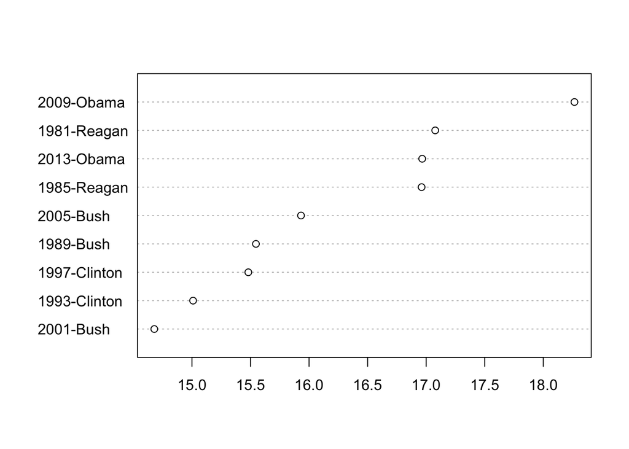

```r
dotchart(sort(lexdiv(myDfm, "R")))
```

We can analyze the **readability** of texts, using `readability()` on a vector of texts or a corpus:

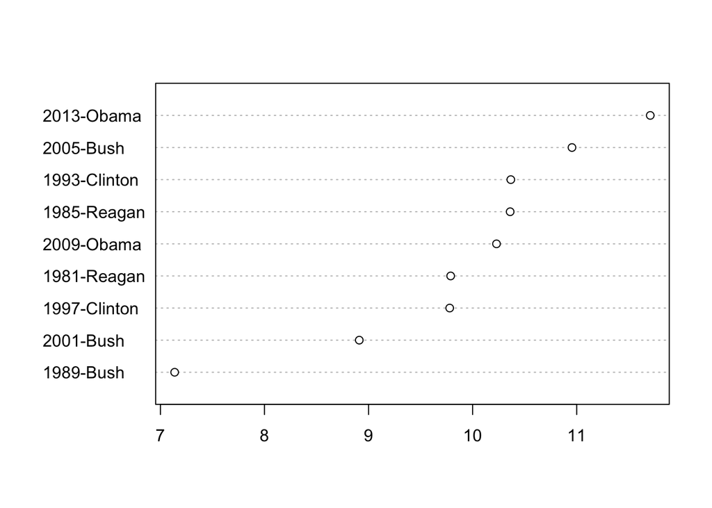

```r
readab <- readability(subset(inaugCorpus, Year > 1980), measure = "Flesch.Kincaid")
dotchart(sort(readab))
```

We can **identify documents and terms that are similar to one another**, using `similarity()`:

```r
## Presidential Inaugural Address Corpus
presDfm <- dfm(inaugCorpus, ignoredFeatures = stopwords("english"))
```

```
## Creating a dfm from a corpus ...
```

```
##
##    ... lowercasing
```

```
##
##    ... tokenizing
```

```
##
##    ... indexing documents: 57 documents
```

```
##
##    ... indexing features:
```

```
## 9,215 feature types
```

```
## ...
```

```
## removed 133 features, from 174 supplied (glob) feature types
```

```
##    ... created a 57 x 9082 sparse dfm
##    ... complete.
## Elapsed time: 1.36 seconds.
```

```r
# compute some document similarities
similarity(presDfm, "1985-Reagan", n=5, margin="documents")
```

```
## similarity Matrix:
## $`1985-Reagan`
##  1981-Reagan 1997-Clinton   2013-Obama   1969-Nixon   1973-Nixon
##       0.6942       0.6595       0.6497       0.6275       0.6262
```

```r
similarity(presDfm, c("2009-Obama" , "2013-Obama"), n = 5, margin = "documents", method = "cosine")
```

```
## similarity Matrix:
## $`2009-Obama`
##   2013-Obama 1997-Clinton  1981-Reagan    1989-Bush  1985-Reagan
##       0.6764       0.6697       0.6320       0.6221       0.6206
##
## $`2013-Obama`
##   2009-Obama  1981-Reagan  1985-Reagan 1997-Clinton    2001-Bush
##       0.6764       0.6627       0.6621       0.6576       0.6206
```

```r
similarity(presDfm, c("2009-Obama" , "2013-Obama"), n = 5, margin = "documents", method = "Hellinger")
```

```
## similarity Matrix:
## $`2009-Obama`
##   2013-Obama 1997-Clinton 1993-Clinton  1985-Reagan    2005-Bush
##       0.4937       0.4898       0.4867       0.4837       0.4818
##
## $`2013-Obama`
## 1997-Clinton   2009-Obama    2001-Bush    2005-Bush 1993-Clinton
##       0.4945       0.4937       0.4909       0.4896       0.4880
```

```r
similarity(presDfm, c("2009-Obama" , "2013-Obama"), n = 5, margin = "documents", method = "eJaccard")
```

```
## similarity Matrix:
## $`2009-Obama`
##   2013-Obama 1997-Clinton  1981-Reagan    1989-Bush   1969-Nixon
##       0.5110       0.4770       0.4563       0.4501       0.4422
##
## $`2013-Obama`
##   2009-Obama  1981-Reagan  1985-Reagan 1997-Clinton    2001-Bush
##       0.5110       0.4877       0.4791       0.4613       0.4418
```

```r
# compute some term similarities
lapply(similarity(presDfm, c("fair", "health", "terror"), margin = "features", method = "cosine"), head)
```

```
## $health
##         culture instrumentality          ideals          denial
##       0.7378648       0.7378648       0.7361216       0.7071068
##      heightened        refusing
##       0.6708204       0.6708204
##
## $fair
##    united     great      best      thus   present  preserve
## 0.7305066 0.7294634 0.7148319 0.7037316 0.7018624 0.6920211
##
## $terror
##      plague     tragedy    mystical       split        atom commonplace
##   0.6708204   0.6708204   0.6708204   0.6708204   0.6708204   0.6708204
```

And this can be used for **clustering documents**:

```r
data(SOTUCorpus, package="quantedaData")
presDfm <- dfm(subset(SOTUCorpus, Date > "1981-01-01"), stem = TRUE,
               ignoredFeatures = stopwords("english"),
               verbose = FALSE)
```

`##`

```r
presDfm <- trim(presDfm, minCount = 5, minDoc = 3)
```

```
## Removing features occurring fewer than 5 times: 4812
```

```
## Removing features occurring in fewer than 3 documents: 4273
```

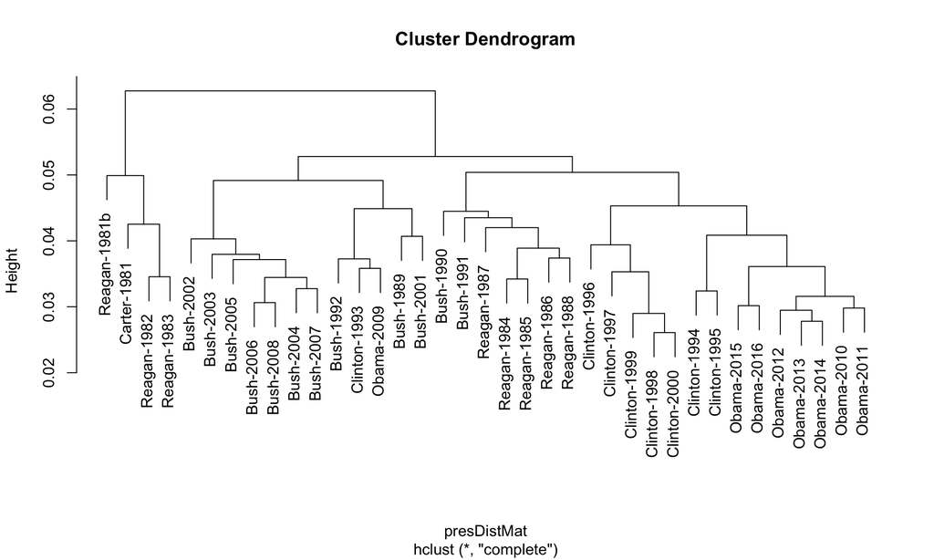

```r
# hierarchical clustering - get distances on normalized dfm
presDistMat <- dist(as.matrix(weight(presDfm, "relFreq")))
# hierarchical clustering the distance object
presCluster <- hclust(presDistMat)
# label with document names
presCluster$labels <- docnames(presDfm)
# plot as a dendrogram
plot(presCluster)
```

Or we could look at **term clustering** insteadd:

```r
# word dendrogram with tf-idf weighting
wordDfm <- sort(weight(presDfm, "tfidf"))
wordDfm <- removeFeatures(wordDfm, "u.") # because it's oddly there
```

```
## removed 1 feature, from 1 supplied (glob) feature types
```

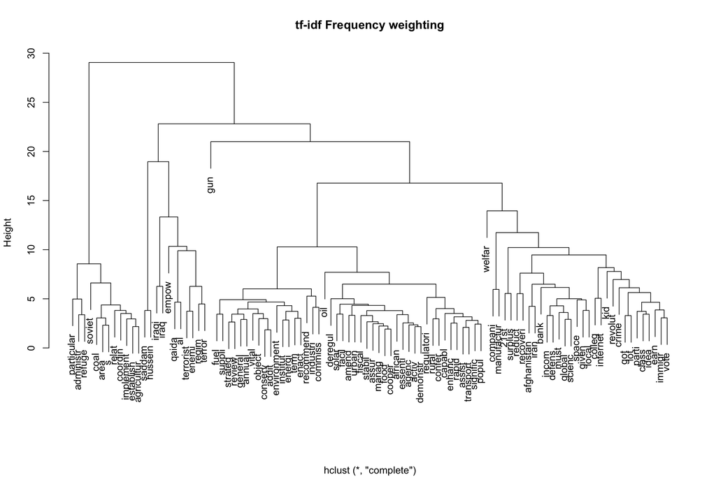

```r
wordDfm <- t(wordDfm)[1:100, ]  # because transposed
wordDistMat <- dist(wordDfm)
wordCluster <- hclust(wordDistMat)
plot(wordCluster, xlab = "", main = "tf-idf Frequency weighting")
```

Finally, there are number of helper functions to extract information from quanteda objects:

```r
myCorpus <- subset(inaugCorpus, Year > 1980)

# return the number of documents
ndoc(myCorpus)
```

```
## [1] 9
```

```r
ndoc(dfm(myCorpus, verbose = FALSE))
```

```
## [1] 9
```

```r
# how many tokens (total words)
ntoken(myCorpus)
```

```
##  1981-Reagan  1985-Reagan    1989-Bush 1993-Clinton 1997-Clinton
##         2798         2935         2683         1837         2451
##    2001-Bush    2005-Bush   2009-Obama   2013-Obama
##         1810         2325         2729         2335
```

```r
ntoken("How many words in this sentence?")
```

```
## [1] 7
```

```r
# arguments to tokenize can be passed
ntoken("How many words in this sentence?", removePunct = TRUE)
```

```
## [1] 6
```

```r
# how many types (unique words)
ntype(myCorpus)
```

```
##  1981-Reagan  1985-Reagan    1989-Bush 1993-Clinton 1997-Clinton
##          904          925          795          644          773
##    2001-Bush    2005-Bush   2009-Obama   2013-Obama
##          622          772          939          814
```

```r
ntype("Yada yada yada.  (TADA.)")
```

```
## [1] 6
```

```r
ntype("Yada yada yada.  (TADA.)", removePunct = TRUE)
```

```
## [1] 3
```

```r
ntype(toLower("Yada yada yada.  (TADA.)"), removePunct = TRUE)
```

```
## [1] 2
```

```r
# can count documents and features
ndoc(inaugCorpus)
```

```
## [1] 57
```

```r
myDfm1 <- dfm(inaugCorpus, verbose = FALSE)
ndoc(myDfm1)
```

```
## [1] 57
```

```r
nfeature(myDfm1)
```

```
## [1] 9215
```

```r
myDfm2 <- dfm(inaugCorpus, ignoredFeatures = stopwords("english"), stem = TRUE, verbose = FALSE)
```

`##`

```r
nfeature(myDfm2)
```

```
## [1] 5303
```

```r
# can extract feature labels and document names
head(features(myDfm1), 20)
```

```
##  [1] "fellow-citizens" "of"              "the"
##  [4] "senate"          "and"             "house"
##  [7] "representatives" "among"           "vicissitudes"
## [10] "incident"        "to"              "life"
## [13] "no"              "event"           "could"
## [16] "have"            "filled"          "me"
## [19] "with"            "greater"
```

```r
head(docnames(myDfm1))
```

```
## [1] "1789-Washington" "1793-Washington" "1797-Adams"      "1801-Jefferson"
## [5] "1805-Jefferson"  "1809-Madison"
```

```r
# and topfeatures
topfeatures(myDfm1)
```

```
##   the    of   and    to    in     a   our  that    we    be
## 10011  7055  5233  4490  2771  2231  2134  1780  1693  1469
```

```r
topfeatures(myDfm2) # without stopwords
```

```
##   will nation govern  peopl     us    can  state   upon  great  power
##    891    662    653    613    476    470    448    371    367    366
```